# Proyecto_rnaseq

Adrian Prieto Castellanos

13/2/2022

# General

El proposito de este proyecto es unificar y poner en practica los conocimientos vistos en el curso de RNA-seq 2022 impartido por Leonardo Collado-Torres para los estudiantes de la Licenciatura en Ciencias Genómicas de la UNAM.

# Datos obtenidos de recount3

Los datos que manejaremos seran del estudio “VenomSeq - 25 venoms vs. IMR-32” con ID SRP185906 basados unicamente por interes del tema.

## Abstract

We report the perturbational effects of 25 crude venoms on human IMR-32 (neuroblastoma) cells. These data are used to evaluate the VenomSeq transcriptomic data analysis workflow, and to provide the first dataset generated by this workflow. By comparison with data published by the Connectivity Map team, and other free sources of genetic perturbation in the context of disease or drug exposure, we use these data to discover several novel associations between venoms and specific therapeutic actions. Overall design: 192 samples total, corresponding to 2 96-well plates of samples. These 192 samples are treated with each of 25 venoms, where extraction takes place at each of 3 time points with 2 replicates per time point (6 samples per venom). 24 samples were treated with water only, and 18 were left untreated. Dosages per venom were determined experimentally as the concentration at which cell growth was inhibited by 20%.

# 01 Librerias Utilizadas

```r
library("recount3")
```

```r
library("ggplot2")
library("edgeR")
library("limma")
library("pheatmap")
```

# 02 Descarga de Datos

Los datos de RNA-seq son descargados a través del paquete recount3 de Bioconductor con el numero de identificador.

```r
human_projects <- (available_projects())
```

```
## 2022-02-14 08:09:37 caching file sra.recount_project.MD.gz.
```

```
## 2022-02-14 08:09:38 caching file gtex.recount_project.MD.gz.
```

```
## 2022-02-14 08:09:39 caching file tcga.recount_project.MD.gz.
```

```r
proj_info <- subset(
    human_projects,
    project == "SRP185906" & project_type == "data_sources"
)
# Crea un objetio de tipo RangedSummarizedExperiment (RSE)
# con la información a nivel de genes
rse_gene_SRP185906 <- create_rse(proj_info)
```

```
## 2022-02-14 08:09:43 downloading and reading the metadata.
```

```
## 2022-02-14 08:09:43 caching file sra.sra.SRP185906.MD.gz.
```

```
## 2022-02-14 08:09:44 caching file sra.recount_project.SRP185906.MD.gz.
```

```
## 2022-02-14 08:09:45 caching file sra.recount_qc.SRP185906.MD.gz.
```

```
## 2022-02-14 08:09:46 caching file sra.recount_seq_qc.SRP185906.MD.gz.
```

```
## 2022-02-14 08:09:47 caching file sra.recount_pred.SRP185906.MD.gz.
```

```
## 2022-02-14 08:09:48 downloading and reading the feature information.
```

```
## 2022-02-14 08:09:48 caching file human.gene_sums.G026.gtf.gz.
```

```
## 2022-02-14 08:09:49 downloading and reading the counts: 192 samples across 63856 features.
```

```
## 2022-02-14 08:09:50 caching file sra.gene_sums.SRP185906.G026.gz.
```

```
## 2022-02-14 08:09:51 construcing the RangedSummarizedExperiment (rse) object.
```

```r
rse_gene_SRP185906
```

```
## class: RangedSummarizedExperiment
## dim: 63856 192
## metadata(8): time_created recount3_version ... annotation recount3_url
## assays(1): raw_counts
## rownames(63856): ENSG00000278704.1 ENSG00000277400.1 ...
##   ENSG00000182484.15_PAR_Y ENSG00000227159.8_PAR_Y
## rowData names(10): source type ... havana_gene tag
## colnames(192): SRR8575687 SRR8575688 ... SRR8575859 SRR8575860
## colData names(175): rail_id external_id ...
##   recount_pred.curated.cell_line BigWigURL
```

```r
assay(rse_gene_SRP185906, "counts") <- compute_read_counts(rse_gene_SRP185906)

rse_gene_SRP185906$sra.sample_attributes
```

```
##   [1] "cell line;;IMR-32|source_name;;IMR-32 neuroblastoma cells in culture|time post-treatment;;6|venom treatment;;1"
##   [2] "cell line;;IMR-32|source_name;;IMR-32 neuroblastoma cells in culture|time post-treatment;;6|venom treatment;;2"
##   [3] "cell line;;IMR-32|source_name;;IMR-32 neuroblastoma cells in culture|time post-treatment;;6|venom treatment;;3"
##   [4] "cell line;;IMR-32|source_name;;IMR-32 neuroblastoma cells in culture|time post-treatment;;6|venom treatment;;4"
##   [5] "cell line;;IMR-32|source_name;;IMR-32 neuroblastoma cells in culture|time post-treatment;;6|venom treatment;;5"
##   [6] "cell line;;IMR-32|source_name;;IMR-32 neuroblastoma cells in culture|time post-treatment;;6|venom treatment;;6"
##   [7] "cell line;;IMR-32|source_name;;IMR-32 neuroblastoma cells in culture|time post-treatment;;6|venom treatment;;7"
##   [8] "cell line;;IMR-32|source_name;;IMR-32 neuroblastoma cells in culture|time post-treatment;;6|venom treatment;;8"
##   [9] "cell line;;IMR-32|source_name;;IMR-32 neuroblastoma cells in culture|time post-treatment;;6|venom treatment;;9"
##  [10] "cell line;;IMR-32|source_name;;IMR-32 neuroblastoma cells in culture|time post-treatment;;6|venom treatment;;10"
##  [11] "cell line;;IMR-32|source_name;;IMR-32 neuroblastoma cells in culture|time post-treatment;;6|venom treatment;;11"
##  [12] "cell line;;IMR-32|source_name;;IMR-32 neuroblastoma cells in culture|time post-treatment;;6|venom treatment;;12"
##  [13] "cell line;;IMR-32|source_name;;IMR-32 neuroblastoma cells in culture|time post-treatment;;6|venom treatment;;13"
##  [14] "cell line;;IMR-32|source_name;;IMR-32 neuroblastoma cells in culture|time post-treatment;;6|venom treatment;;14"
##  [15] "cell line;;IMR-32|source_name;;IMR-32 neuroblastoma cells in culture|time post-treatment;;6|venom treatment;;15"
```

[output cut: 177 more lines]

# 03 Limpieza y Formateo

Para que el manejo de los datos sea el correcto debemos asegurarnos que la informacion de cada categoria permita su uso sin problemas y en todo caso darle el formato correcto. Una vez descargados los datos y con los números de lecturas usamos expand_sra_attributes()

```r
#Una vez descargados los datos y con los números de lecturas usamos expand_sra_attributes()
#Para revisar los atributos de estos
rse_gene_SRP185906 <- expand_sra_attributes(rse_gene_SRP185906)
colData(rse_gene_SRP185906)[
    ,
    grepl("^sra_attribute", colnames(colData(rse_gene_SRP185906)))
]
```

```
## DataFrame with 192 rows and 4 columns
##            sra_attribute.cell_line sra_attribute.source_name
##                        <character>               <character>
## SRR8575687                  IMR-32    IMR-32 neuroblastoma..
## SRR8575688                  IMR-32    IMR-32 neuroblastoma..
## SRR8575689                  IMR-32    IMR-32 neuroblastoma..
## SRR8575690                  IMR-32    IMR-32 neuroblastoma..
## SRR8575691                  IMR-32    IMR-32 neuroblastoma..
## ...                            ...                       ...
## SRR8575856                  IMR-32    IMR-32 neuroblastoma..
## SRR8575857                  IMR-32    IMR-32 neuroblastoma..
## SRR8575858                  IMR-32    IMR-32 neuroblastoma..
## SRR8575859                  IMR-32    IMR-32 neuroblastoma..
## SRR8575860                  IMR-32    IMR-32 neuroblastoma..
##            sra_attribute.time_post-treatment sra_attribute.venom_treatment
##                                  <character>                   <character>
## SRR8575687                                 6                             1
## SRR8575688                                 6                             2
## SRR8575689                                 6                             3
## SRR8575690                                 6                             4
## SRR8575691                                 6                             5
## ...                                      ...                           ...
## SRR8575856                                 6                         Water
## SRR8575857                                 6                         Water
## SRR8575858                                 6                         Water
## SRR8575859                                 6                         Water
## SRR8575860                                 6                     Untreated
```

Como podemos observar contamos con estos atributos. cell_line source_name time_post-treatment venom_treatment

```r
# Pasar de character a nuemric o factor
rse_gene_SRP185906$sra_attribute.cell_line <- factor(rse_gene_SRP185906$sra_attribute.cell_line)
rse_gene_SRP185906$sra_attribute.source_name <- factor(rse_gene_SRP185906$sra_attribute.source_name)
rse_gene_SRP185906$`sra_attribute.time_post-treatment` <- as.numeric(rse_gene_SRP185906$`sra_attribute.time_post-treatment`)
rse_gene_SRP185906$sra_attribute.venom_treatment <- factor(rse_gene_SRP185906$sra_attribute.venom_treatment)
# Revisar nuestras variables de interes
summary(as.data.frame(colData(rse_gene_SRP185906)[
grepl("^sra_attribute.[cell_line|source_name|time_post-treatmen|venom_treatment]", colnames(colData(rse_gene_SRP185906)))
]))
```

```
##  sra_attribute.cell_line                         sra_attribute.source_name
##  IMR-32:192              IMR-32 neuroblastoma cells in culture:192
##
##
##
##
##
##
##  sra_attribute.time_post.treatment sra_attribute.venom_treatment
##  Min.   : 6                        Water    : 24
##  1st Qu.: 6                        Untreated: 18
##  Median :24                        1        :  6
##  Mean   :22                        10       :  6
##  3rd Qu.:36                        11       :  6
##  Max.   :36                        12       :  6
##                                    (Other)  :126
```

# 04 Crear nuestra variable categorica

Creamos la categoria time para dividir en tres los tiempos depues del tratamiento con el veneno o agua.

```r
rse_gene_SRP185906$time <- factor(ifelse(rse_gene_SRP185906$`sra_attribute.time_post-treatment`== 6, "Tiempo1", ifelse(rse_gene_SRP185906$`sra_attribute.time_post-treatment`== 24, "Tiempo2","Tiempo3")))
rse_gene_SRP185906$time
```

```
##   [1] Tiempo1 Tiempo1 Tiempo1 Tiempo1 Tiempo1 Tiempo1 Tiempo1 Tiempo1 Tiempo1
##  [10] Tiempo1 Tiempo1 Tiempo1 Tiempo1 Tiempo1 Tiempo1 Tiempo1 Tiempo1 Tiempo1
##  [19] Tiempo1 Tiempo1 Tiempo1 Tiempo1 Tiempo1 Tiempo1 Tiempo1 Tiempo1 Tiempo1
##  [28] Tiempo1 Tiempo1 Tiempo1 Tiempo1 Tiempo1 Tiempo2 Tiempo2 Tiempo2 Tiempo2
##  [37] Tiempo2 Tiempo2 Tiempo2 Tiempo2 Tiempo2 Tiempo2 Tiempo2 Tiempo2 Tiempo2
##  [46] Tiempo2 Tiempo2 Tiempo2 Tiempo2 Tiempo2 Tiempo2 Tiempo2 Tiempo2 Tiempo2
##  [55] Tiempo2 Tiempo2 Tiempo2 Tiempo2 Tiempo2 Tiempo2 Tiempo2 Tiempo2 Tiempo2
##  [64] Tiempo2 Tiempo3 Tiempo3 Tiempo3 Tiempo3 Tiempo3 Tiempo3 Tiempo3 Tiempo2
##  [73] Tiempo2 Tiempo2 Tiempo2 Tiempo2 Tiempo2 Tiempo2 Tiempo2 Tiempo2 Tiempo2
##  [82] Tiempo2 Tiempo2 Tiempo2 Tiempo3 Tiempo3 Tiempo3 Tiempo3 Tiempo3 Tiempo3
##  [91] Tiempo3 Tiempo3 Tiempo3 Tiempo3 Tiempo3 Tiempo3 Tiempo3 Tiempo3 Tiempo3
## [100] Tiempo3 Tiempo3 Tiempo3 Tiempo3 Tiempo3 Tiempo3 Tiempo3 Tiempo3 Tiempo3
## [109] Tiempo3 Tiempo3 Tiempo3 Tiempo3 Tiempo1 Tiempo1 Tiempo1 Tiempo1 Tiempo1
## [118] Tiempo1 Tiempo1 Tiempo1 Tiempo1 Tiempo1 Tiempo1 Tiempo1 Tiempo1 Tiempo1
## [127] Tiempo1 Tiempo1 Tiempo1 Tiempo1 Tiempo1 Tiempo1 Tiempo1 Tiempo1 Tiempo1
## [136] Tiempo1 Tiempo1 Tiempo1 Tiempo1 Tiempo2 Tiempo2 Tiempo2 Tiempo2 Tiempo2
## [145] Tiempo2 Tiempo2 Tiempo2 Tiempo2 Tiempo2 Tiempo2 Tiempo2 Tiempo2 Tiempo2
## [154] Tiempo2 Tiempo2 Tiempo3 Tiempo2 Tiempo2 Tiempo2 Tiempo3 Tiempo3 Tiempo3
## [163] Tiempo3 Tiempo3 Tiempo3 Tiempo3 Tiempo3 Tiempo3 Tiempo3 Tiempo3 Tiempo3
## [172] Tiempo3 Tiempo3 Tiempo3 Tiempo3 Tiempo3 Tiempo3 Tiempo3 Tiempo3 Tiempo3
## [181] Tiempo3 Tiempo3 Tiempo3 Tiempo3 Tiempo3 Tiempo3 Tiempo3 Tiempo1 Tiempo1
## [190] Tiempo1 Tiempo1 Tiempo1
## Levels: Tiempo1 Tiempo2 Tiempo3
```

```r
table(rse_gene_SRP185906$time)
```

```
##
## Tiempo1 Tiempo2 Tiempo3
##      64      64      64
```

# 05 Filtrado de datos

A continuación podemos eliminar algunas muestras que consideremos de baja calidad o genes con niveles de expresión muy bajos.

```r
rse_gene_SRP185906$assigned_gene_prop <- rse_gene_SRP185906$recount_qc.gene_fc_count_all.assigned / rse_gene_SRP185906$recount_qc.gene_fc_count_all.total
summary(rse_gene_SRP185906$assigned_gene_prop)
```

```
##    Min. 1st Qu.  Median    Mean 3rd Qu.    Max.
##  0.4461  0.4936  0.5008  0.4998  0.5061  0.5239
```

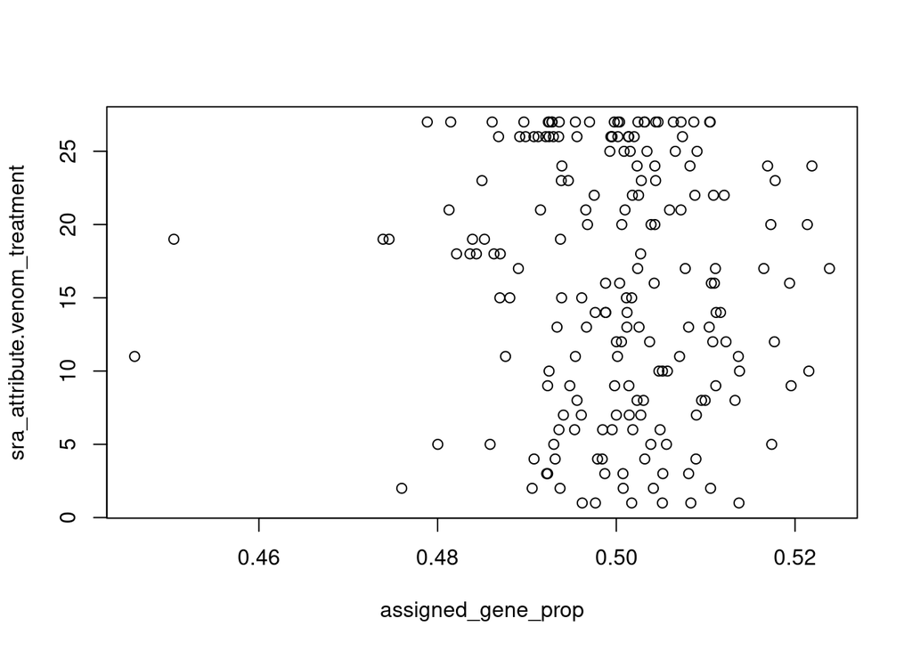

```r
with(colData(rse_gene_SRP185906), plot(assigned_gene_prop, sra_attribute.venom_treatment))
```

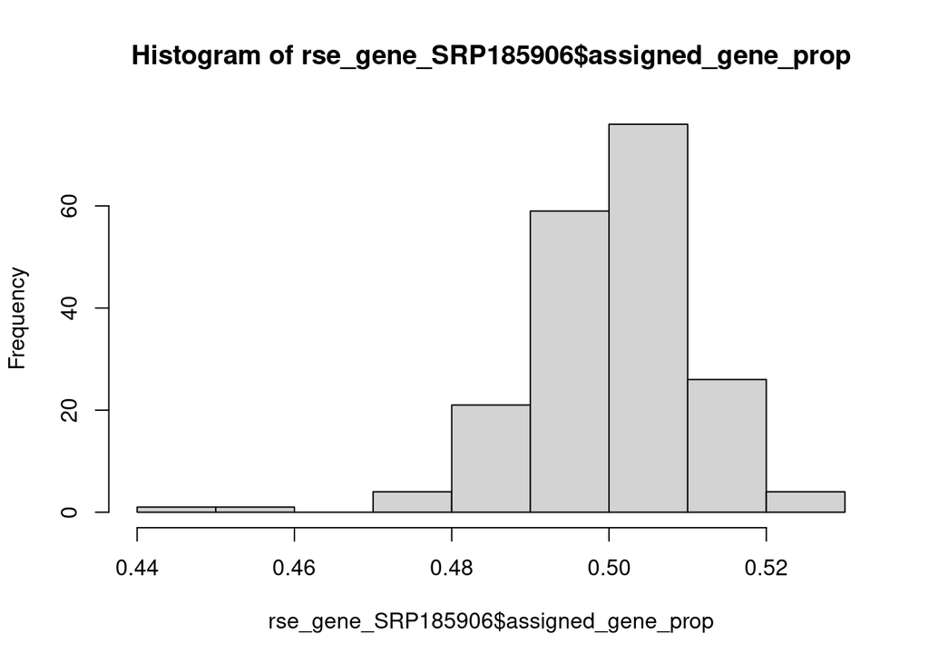

```r
# Guardemos nuestro objeto entero como respaldo
rse_gene_SRP185906_unfiltered <- rse_gene_SRP185906
rse_gene_SRP185906 <- rse_gene_SRP185906_unfiltered
hist(rse_gene_SRP185906$assigned_gene_prop)
```

```r
table(rse_gene_SRP185906$assigned_gene_prop <= 0.46)
```

```
##
## FALSE  TRUE
##   190     2
```

```r
# Cortamos las muestas de mala calidad
rse_gene_SRP185906 <- rse_gene_SRP185906[, rse_gene_SRP185906$assigned_gene_prop > 0.46]
```

```r
# Calculemos los niveles medios de expresión de los genes en nuestras
# muestras.
gene_means <- rowMeans(assay(rse_gene_SRP185906, "counts"))
summary(gene_means)
```

```
##      Min.   1st Qu.    Median      Mean   3rd Qu.      Max.
##      0.00      0.00      0.03     38.80      1.81 105365.51
```

```r
#Cortamos las muestras menores al primer cuartil
rse_gene_SRP185906 <- rse_gene_SRP185906[gene_means > 0.00, ]
dim(rse_gene_SRP185906)
```

```
## [1] 39977   190
```

```r
round(nrow(rse_gene_SRP185906) / nrow(rse_gene_SRP185906_unfiltered) * 100, 2)
```

```
## [1] 62.6
```

# 06 Normalizacion y visualizacion de datos

```r
dge <- DGEList(
    counts = assay(rse_gene_SRP185906, "counts"),
    genes = rowData(rse_gene_SRP185906)
)
dge <- calcNormFactors(dge)
```

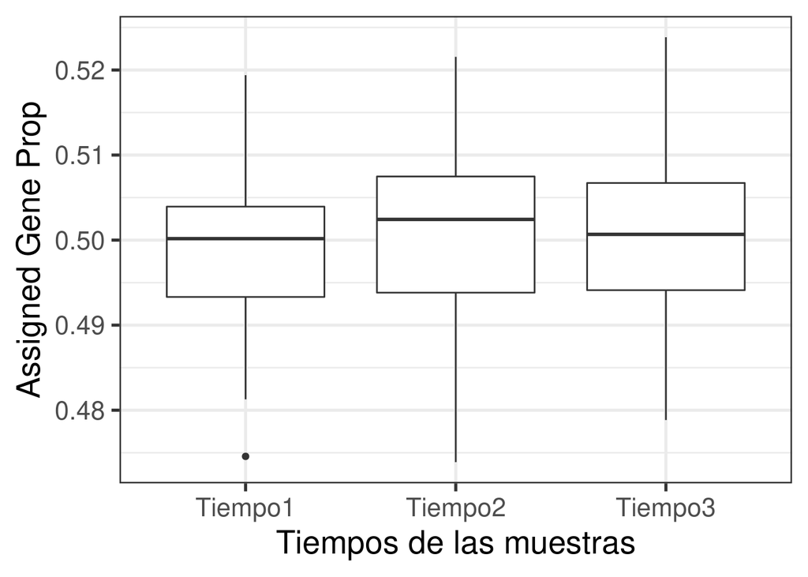

```r
ggplot(as.data.frame(colData(rse_gene_SRP185906)), aes(y = assigned_gene_prop, x = time)) +
    geom_boxplot() +
    theme_bw(base_size = 20) +
    ylab("Assigned Gene Prop") +
    xlab("Tiempos de las muestras")
```

# 07 Modelo estadistico. Utilizamos model.matrix() para modelar las distintas categorías de nuestro interes para despues analizarlas, esto nos ayudara con el analizis de expresion diferencial.

```r
mod <- model.matrix(~time + sra_attribute.venom_treatment + assigned_gene_prop,
    data = colData(rse_gene_SRP185906)
    )
colnames(mod)
```

```
##  [1] "(Intercept)"
##  [2] "timeTiempo2"
##  [3] "timeTiempo3"
##  [4] "sra_attribute.venom_treatment10"
##  [5] "sra_attribute.venom_treatment11"
##  [6] "sra_attribute.venom_treatment12"
##  [7] "sra_attribute.venom_treatment13"
##  [8] "sra_attribute.venom_treatment14"
##  [9] "sra_attribute.venom_treatment15"
## [10] "sra_attribute.venom_treatment16"
## [11] "sra_attribute.venom_treatment17"
## [12] "sra_attribute.venom_treatment18"
## [13] "sra_attribute.venom_treatment19"
## [14] "sra_attribute.venom_treatment2"
## [15] "sra_attribute.venom_treatment20"
## [16] "sra_attribute.venom_treatment21"
## [17] "sra_attribute.venom_treatment22"
## [18] "sra_attribute.venom_treatment23"
## [19] "sra_attribute.venom_treatment24"
## [20] "sra_attribute.venom_treatment25"
## [21] "sra_attribute.venom_treatment3"
## [22] "sra_attribute.venom_treatment4"
## [23] "sra_attribute.venom_treatment5"
## [24] "sra_attribute.venom_treatment6"
## [25] "sra_attribute.venom_treatment7"
## [26] "sra_attribute.venom_treatment8"
## [27] "sra_attribute.venom_treatment9"
## [28] "sra_attribute.venom_treatmentUntreated"
## [29] "sra_attribute.venom_treatmentWater"
## [30] "assigned_gene_prop"
```

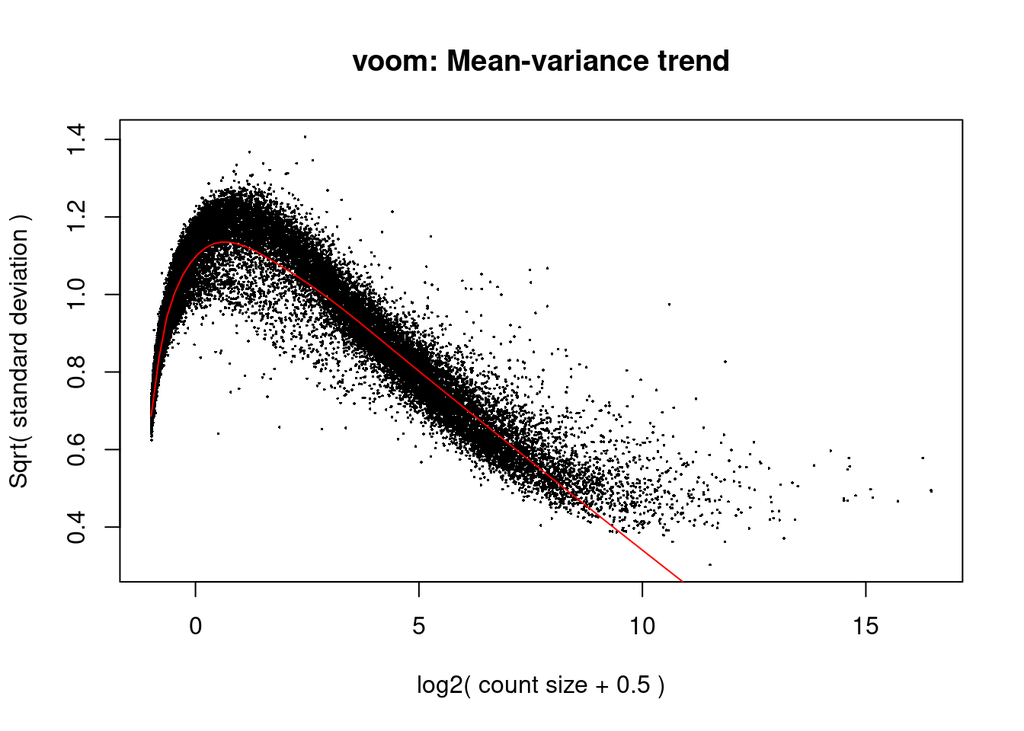

```r
vGene <- voom(dge, mod, plot = TRUE)
```

```r
eb_results <- eBayes(lmFit(vGene))
de_results <- topTable(
    eb_results,
    coef = 3,
    number = nrow(rse_gene_SRP185906),
    sort.by = "none"
)
dim(de_results)
```

```
## [1] 39977    16
```

```r
head(de_results)
```

```
##                   source type bp_length phase           gene_id
## ENSG00000223972.5 HAVANA gene      1735    NA ENSG00000223972.5
## ENSG00000227232.5 HAVANA gene      1351    NA ENSG00000227232.5
## ENSG00000243485.5 HAVANA gene      1021    NA ENSG00000243485.5
## ENSG00000237613.2 HAVANA gene      1219    NA ENSG00000237613.2
## ENSG00000239945.1 HAVANA gene      1319    NA ENSG00000239945.1
## ENSG00000238009.6 HAVANA gene      3726    NA ENSG00000238009.6
##                                            gene_type    gene_name level
## ENSG00000223972.5 transcribed_unprocessed_pseudogene      DDX11L1     2
## ENSG00000227232.5             unprocessed_pseudogene       WASH7P     2
## ENSG00000243485.5                            lincRNA  MIR1302-2HG     2
## ENSG00000237613.2                            lincRNA      FAM138A     2
## ENSG00000239945.1                            lincRNA RP11-34P13.8     2
## ENSG00000238009.6                            lincRNA RP11-34P13.7     2
##                            havana_gene               tag      logFC     AveExpr
## ENSG00000223972.5 OTTHUMG00000000961.2              <NA> 0.16632984  0.05148802
## ENSG00000227232.5 OTTHUMG00000000958.1              <NA> 0.18387082 -1.31981066
## ENSG00000243485.5 OTTHUMG00000000959.2        ncRNA_host 0.06625631 -1.97163328
## ENSG00000237613.2 OTTHUMG00000000960.1              <NA> 0.12754101 -2.06852449
## ENSG00000239945.1 OTTHUMG00000001097.2 overlapping_locus 0.29697456 -2.00237360
## ENSG00000238009.6 OTTHUMG00000001096.2 overlapping_locus 0.29381215 -1.94200974
##                           t     P.Value  adj.P.Val          B
## ENSG00000223972.5 0.7430713 0.458492322 0.63694373 -5.1845832
## ENSG00000227232.5 1.1809005 0.239337107 0.45277579 -4.9400513
## ENSG00000243485.5 0.7522539 0.452967290 0.63282451 -5.7125827
## ENSG00000237613.2 1.9001716 0.059150017 0.26976451 -4.3364424
## ENSG00000239945.1 3.5027506 0.000592265 0.02266031 -0.4076893
## ENSG00000238009.6 2.7739896 0.006173947 0.10511749 -2.4123214
```

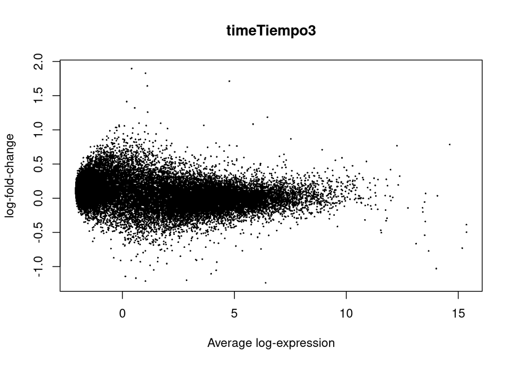

```r
plotMA(eb_results, coef = 3)
```

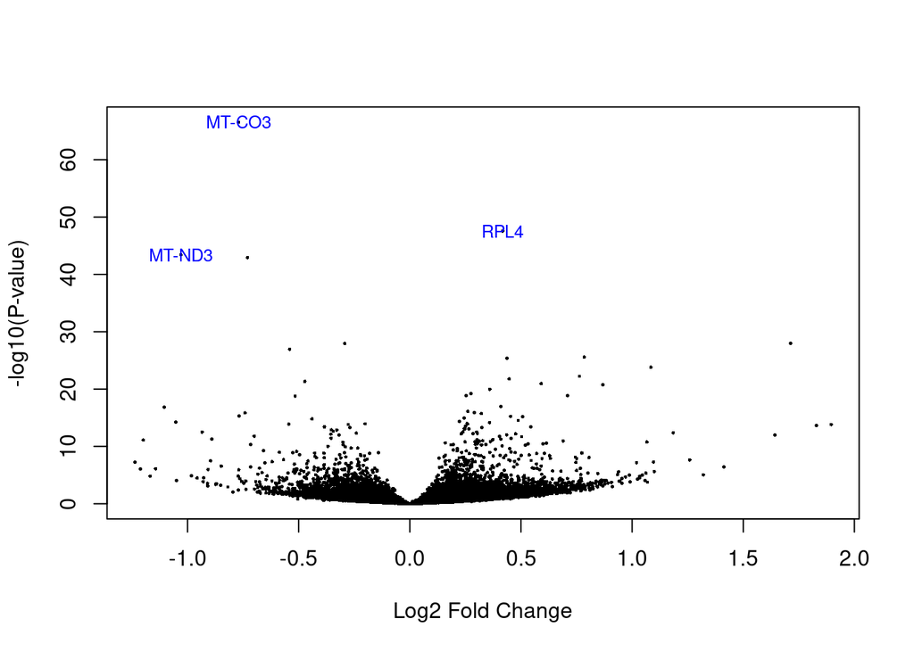

```r
volcanoplot(eb_results, coef = 3, highlight = 3, names = de_results$gene_name)
```

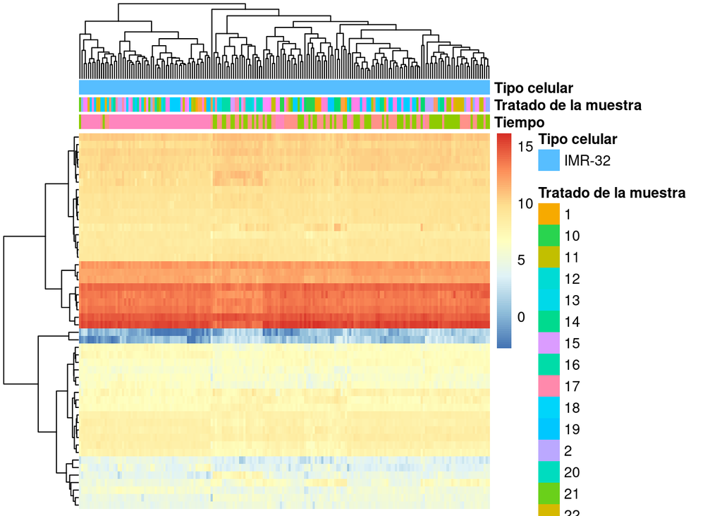

```r
#Creamos un heatmap para visualizar la expresion de las diferentes muestras
exprs_heatmap <- vGene$E[rank(de_results$adj.P.Val) <= 50, ]

df <- as.data.frame(colData(rse_gene_SRP185906)[, c("time", "sra_attribute.venom_treatment", "sra_attribute.cell_line")])
colnames(df) <- c("Tiempo", "Tratado de la muestra", "Tipo celular")

library("pheatmap")
pheatmap(
    exprs_heatmap,
    cluster_rows = TRUE,
    cluster_cols = TRUE,
    show_rownames = FALSE,
    show_colnames = FALSE,
    annotation_col = df
)
```

# Concluciones.

Como podemos ver la espresion de los genes no varia tanto en la mayoria de las muestras, pudiendo concluir que existe una cierta uniformidad en la que los vevenos afectan la expresion en los genes. Este proyecto me resulto curioso por los analizis hechos y las librerias tan utiles que ocupamos, ademas de poder acercarnos a analisis con datos reales.